# Predicting Race Outcomes in Formula 1

Tyler Campbell

11/20/2019

## Project Introduction

This report contains findings and highlights steps taken during Stage 2 (of 3) of a team project in **MIS 545 - Data Mining for Business Intelligence**, taught by Dr. Bin Zhang.

The requirements of this stage are for team members to independently test different data subsets or algorithms, or to try a different approach altogether (as compared to Stage 1). In Stage 3, the team will regroup and build off eachother’s analysis.

## Problem Description

Apart from the extreme financial demands of the sport, one of the great challenges in F1 is for team principals and strategists to decide which of their two drivers to prioritize in a race. Sometimes there is a clear cut difference over which driver is faster (thus deserving preferential treatment) and other times there is not. Being able to better predict race outcomes would allow for more effective team strategizing.

## Team vs Individual Approaches

In Stage 1 of the project, the team set out to predict order of podium finishers (i.e. top 3) in a given race based off individual lap data from 2011 to 2017. We incorporated C5.0, SVM, and Naieve Bayes classifer algorithms. The findings produced fair accuracy, but their usefulness was limited due to only considering outcomes of 3 drivers and only building off data from a 6 year window. Having the granularity at lap times as opposed to race results also resulted in problematic redundancies.

Given these shortfalls, for Stage 2 I chose to re-structure the dataset to include race results dating back to 1950. The process required extensive cleaning, but ultimately allowed me to predict whether or not a racer would finish ‘in the points’ (i.e. top 10) or ‘out of the points’, which seemed like much more useful findings. Once this had been performed, I went back and incorporated an additional dataset to obtain driver home town geocordinates.

In the end, the algorithms that I ran in R were: * **K-Means** on where drivers are from geographicaly (values were reassigned to the dataset) * **Naieve Bayes** to predict whether or not a racer finished ‘in the points’

## Dataset Description

Data for this project was obtained from Kaggle (https://www.kaggle.com/cjgdev/formula-1-race-data-19502017), originally sourced from Ergast Developer API (https://ergast.com/mrd/) at the conclusion of the 2017 season. Data on ergast is gathered and published to the public domain by Chris Newell.

**circuits:** every circuit name, location, and wiki page url

```
## [1] 73  9
```

```
##    circuitId   circuitRef            name             location
##  Min.   : 1   Length:73          Length:73          Length:73
##  1st Qu.:19   Class :character   Class :character   Class :character
##  Median :37   Mode  :character   Mode  :character   Mode  :character
##  Mean   :37
##  3rd Qu.:55
##  Max.   :73
##
##    country               lat              lng                alt
##  Length:73          Min.   :-37.85   Min.   :-118.189   Min.   :10
##  Class :character   1st Qu.: 33.58   1st Qu.:  -9.394   1st Qu.:10
##  Mode  :character   Median : 41.37   Median :   3.931   Median :10
##                     Mean   : 33.87   Mean   :   1.723   Mean   :10
##                     3rd Qu.: 47.22   3rd Qu.:  14.765   3rd Qu.:10
##                     Max.   : 57.27   Max.   : 144.968   Max.   :10
##                                                         NA's   :72
##      url
##  Length:73
##  Class :character
##  Mode  :character
##
##
##
##
```

**constructorResults:** aggregated constructor points earned per race

```
## [1] 11142     5
```

```
##  constructorResultsId     raceId      constructorId        points
##  Min.   :    1        Min.   :  1.0   Min.   :  1.00   Min.   : 0.000
##  1st Qu.: 2786        1st Qu.:259.2   1st Qu.:  6.00   1st Qu.: 0.000
##  Median : 5572        Median :440.0   Median : 23.00   Median : 0.000
##  Mean   : 7364        Mean   :456.4   Mean   : 41.25   Mean   : 3.193
##  3rd Qu.:12823        3rd Qu.:628.0   3rd Qu.: 50.00   3rd Qu.: 4.000
##  Max.   :15639        Max.   :988.0   Max.   :210.00   Max.   :66.000
##     status
##  Length:11142
##  Class :character
##  Mode  :character
##
##
##
```

- ‘D’ in ‘status’ column represents ‘Disqualified’ due to Spygate scandal in 2007 season (https://en.wikipedia.org/wiki/2007_Formula_One_espionage_controversy)

**constructors:** every constructor name, nationality, and wiki page url

```
## [1] 208   6
```

```
##  constructorId    constructorRef         name           nationality
##  Min.   :  1.00   Length:208         Length:208         Length:208
##  1st Qu.: 53.75   Class :character   Class :character   Class :character
##  Median :105.50   Mode  :character   Mode  :character   Mode  :character
##  Mean   :105.51
##  3rd Qu.:157.25
##  Max.   :210.00
##      url               X
##  Length:208         Mode:logical
##  Class :character   NA's:208
##  Mode  :character
##
##
##
```

- constructors are teams (e.g. Ferrari, Williams, Red Bull, etc.)
- in modern racing era there are 10 constructors with 2 drivers each

**constructorStandings:** running/accumulated ‘points’ and ‘wins’ for constructors in a given season

```
## [1] 11896     8
```

```
##  constructorStandingsId     raceId      constructorId        points
##  Min.   :    1          Min.   :  1.0   Min.   :  1.00   Min.   :  0.00
##  1st Qu.: 8245          1st Qu.:274.0   1st Qu.:  6.00   1st Qu.:  0.00
##  Median :17760          Median :463.0   Median : 25.00   Median :  6.00
##  Mean   :15201          Mean   :469.1   Mean   : 45.67   Mean   : 27.14
##  3rd Qu.:23302          3rd Qu.:658.0   3rd Qu.: 56.00   3rd Qu.: 25.00
##  Max.   :26932          Max.   :988.0   Max.   :210.00   Max.   :765.00
##     position      positionText            wins            X
##  Min.   : 1.000   Length:11896       Min.   : 0.0000   Mode:logical
##  1st Qu.: 4.000   Class :character   1st Qu.: 0.0000   NA's:11896
##  Median : 7.000   Mode  :character   Median : 0.0000
##  Mean   : 7.441                      Mean   : 0.6443
##  3rd Qu.:10.000                      3rd Qu.: 0.0000
##  Max.   :22.000                      Max.   :19.0000
```

**drivers:** every driver name, number, dob, nationality, and wiki page url

```
## [1] 842   9
```

```
##     driverId      driverRef             number          code
##  Min.   :  1.0   Length:842         Min.   : 2.00   Length:842
##  1st Qu.:211.2   Class :character   1st Qu.:10.25   Class :character
##  Median :421.5   Mode  :character   Median :21.50   Mode  :character
##  Mean   :421.5                      Mean   :30.50
##  3rd Qu.:631.8                      3rd Qu.:38.25
##  Max.   :843.0                      Max.   :99.00
##                                     NA's   :804
##    forename           surname              dob
##  Length:842         Length:842         Length:842
##  Class :character   Class :character   Class :character
##  Mode  :character   Mode  :character   Mode  :character
##
##
##
##
##  nationality            url
##  Length:842         Length:842
##  Class :character   Class :character
##  Mode  :character   Mode  :character
##
##
##
##
```

- create feature that contains driver age at time of race

**driverStandings:** accumulated driver points and wins for a given season

```
## [1] 31726     7
```

```
##  driverStandingsId     raceId         driverId         points
##  Min.   :    1     Min.   :  1.0   Min.   :  1.0   Min.   :  0.00
##  1st Qu.:18503     1st Qu.:329.0   1st Qu.: 84.0   1st Qu.:  0.00
##  Median :47758     Median :566.0   Median :205.0   Median :  0.00
##  Mean   :39545     Mean   :537.9   Mean   :280.2   Mean   : 10.62
##  3rd Qu.:56742     3rd Qu.:769.0   3rd Qu.:437.0   3rd Qu.:  8.00
##  Max.   :68608     Max.   :988.0   Max.   :843.0   Max.   :397.00
##     position      positionText            wins
##  Min.   :  1.00   Length:31726       Min.   : 0.000
##  1st Qu.:  9.00   Class :character   1st Qu.: 0.000
##  Median : 17.00   Mode  :character   Median : 0.000
##  Mean   : 20.57                      Mean   : 0.252
##  3rd Qu.: 27.00                      3rd Qu.: 0.000
##  Max.   :108.00                      Max.   :13.000
```

- thought: if you could associate a race with its round #, then driver with most points after final round wins championship

**lapTimes:** lap time and position for each driver in each lap of each race

```
## [1] 426633      6
```

```
##      raceId         driverId          lap           position
##  Min.   :  1.0   Min.   :  1.0   Min.   : 1.00   Min.   : 1.000
##  1st Qu.:100.0   1st Qu.: 14.0   1st Qu.:14.00   1st Qu.: 5.000
##  Median :205.0   Median : 26.0   Median :29.00   Median : 9.000
##  Mean   :423.1   Mean   :186.5   Mean   :29.83   Mean   : 9.647
##  3rd Qu.:881.0   3rd Qu.: 71.0   3rd Qu.:44.00   3rd Qu.:14.000
##  Max.   :988.0   Max.   :843.0   Max.   :78.00   Max.   :24.000
##      time            milliseconds
##  Length:426633      Min.   :  67411
##  Class :character   1st Qu.:  82382
##  Mode  :character   Median :  90800
##                     Mean   :  95802
##                     3rd Qu.: 102738
##                     Max.   :7507547
```

- file is missing lap times from at least races 400-800 (by raceID)
- consider excluding lap 25 of raceId 847 (2011 Canadian Grand Prix had “torrential rains” that caused a single lap to clock in at over 2 hrs)
- consider excluding file altogether

**pitStops:** stop number and stop duration/milliseconds of each pitstop at a given time of day on a given lap by a given driver

```
## [1] 6251    7
```

```
##      raceId         driverId          stop            lap
##  Min.   :841.0   Min.   :  1.0   Min.   :1.000   Min.   : 1.00
##  1st Qu.:868.0   1st Qu.: 13.0   1st Qu.:1.000   1st Qu.:13.00
##  Median :902.0   Median :807.0   Median :2.000   Median :24.00
##  Mean   :907.9   Mean   :429.5   Mean   :1.836   Mean   :24.81
##  3rd Qu.:950.0   3rd Qu.:821.0   3rd Qu.:2.000   3rd Qu.:35.00
##  Max.   :988.0   Max.   :843.0   Max.   :6.000   Max.   :74.00
##      time             duration          milliseconds
##  Length:6251        Length:6251        Min.   :  12897
##  Class :character   Class :character   1st Qu.:  21768
##  Mode  :character   Mode  :character   Median :  23340
##                                        Mean   :  47744
##                                        3rd Qu.:  25547
##                                        Max.   :2011266
```

- file excludes races before 2011 and after 2017
- consider aggregating ‘milliseconds’ per driver per race to obtain a single total pit time per race
- consider obtaining largest number of ‘stop’ per driver per race to get total number of pit stops per race
- consider excluding file altogether

**qualifying:** qualifying times (and final qualifying position) for each driver of each race

```
## [1] 7516    9
```

```
##    qualifyId        raceId         driverId     constructorId
##  Min.   :   1   Min.   :  1.0   Min.   :  1.0   Min.   :  1.00
##  1st Qu.:1880   1st Qu.: 91.0   1st Qu.: 14.0   1st Qu.:  4.00
##  Median :3760   Median :259.0   Median : 30.0   Median :  9.00
##  Mean   :3763   Mean   :449.8   Mean   :203.8   Mean   : 34.76
##  3rd Qu.:5639   3rd Qu.:887.0   3rd Qu.:111.0   3rd Qu.: 19.00
##  Max.   :7539   Max.   :988.0   Max.   :843.0   Max.   :210.00
##      number         position          q1                 q2
##  Min.   : 0.00   Min.   : 1.00   Length:7516        Length:7516
##  1st Qu.: 7.00   1st Qu.: 6.00   Class :character   Class :character
##  Median :12.00   Median :11.00   Mode  :character   Mode  :character
##  Mean   :15.29   Mean   :11.47
##  3rd Qu.:20.00   3rd Qu.:17.00
##  Max.   :99.00   Max.   :28.00
##       q3
##  Length:7516
##  Class :character
##  Mode  :character
##
##
##
```

- the process of qualifying determines grid position at start of race
- the slowest drivers (e.g. bottom 5) get knocked out after each round of qualifying
- ‘position’ should be the same as grid in results file
- consider excluding file altogether because of NAs

**races:** race name, date, and time for each seasons, and wiki page url

```
## [1] 997   8
```

```
##      raceId          year          round          circuitId
##  Min.   :   1   Min.   :1950   Min.   : 1.000   Min.   : 1.00
##  1st Qu.: 250   1st Qu.:1974   1st Qu.: 4.000   1st Qu.: 9.00
##  Median : 499   Median :1990   Median : 8.000   Median :18.00
##  Mean   : 500   Mean   :1989   Mean   : 8.234   Mean   :21.76
##  3rd Qu.: 748   3rd Qu.:2005   3rd Qu.:12.000   3rd Qu.:30.00
##  Max.   :1009   Max.   :2018   Max.   :21.000   Max.   :73.00
##      name               date               time
##  Length:997         Length:997         Length:997
##  Class :character   Class :character   Class :character
##  Mode  :character   Mode  :character   Mode  :character
##
##
##
##      url
##  Length:997
##  Class :character
##  Mode  :character
##
##
##
```

- race time is empty from 1950 to 2005
- consider removing ‘time’
- remove ‘name’ which will be redundant after merge (circuits table contains ref)

**results:** results of every race (*critical file containing dependent variables*)

```
## [1] 23777    18
```

```
##     resultId         raceId         driverId     constructorId
##  Min.   :    1   Min.   :  1.0   Min.   :  1.0   Min.   :  1.00
##  1st Qu.: 5945   1st Qu.:273.0   1st Qu.: 55.0   1st Qu.:  6.00
##  Median :11889   Median :478.0   Median :154.0   Median : 25.00
##  Mean   :11889   Mean   :487.2   Mean   :226.5   Mean   : 46.28
##  3rd Qu.:17833   3rd Qu.:718.0   3rd Qu.:314.0   3rd Qu.: 57.00
##  Max.   :23781   Max.   :988.0   Max.   :843.0   Max.   :210.00
##
##      number            grid          position      positionText
##  Min.   :  0.00   Min.   : 0.00   Min.   : 1.000   Length:23777
##  1st Qu.:  7.00   1st Qu.: 5.00   1st Qu.: 4.000   Class :character
##  Median : 15.00   Median :11.00   Median : 7.000   Mode  :character
##  Mean   : 16.97   Mean   :11.27   Mean   : 7.782
##  3rd Qu.: 23.00   3rd Qu.:17.00   3rd Qu.:11.000
##  Max.   :208.00   Max.   :34.00   Max.   :33.000
##  NA's   :6                        NA's   :10550
##  positionOrder       points            laps            time
##  Min.   : 1.00   Min.   : 0.000   Min.   :  0.00   Length:23777
##  1st Qu.: 7.00   1st Qu.: 0.000   1st Qu.: 20.00   Class :character
##  Median :13.00   Median : 0.000   Median : 52.00   Mode  :character
##  Mean   :13.08   Mean   : 1.601   Mean   : 45.27
##  3rd Qu.:19.00   3rd Qu.: 1.000   3rd Qu.: 66.00
##  Max.   :39.00   Max.   :50.000   Max.   :200.00
##
##   milliseconds        fastestLap         rank       fastestLapTime
##  Min.   : 1474899   Min.   : 2.00   Min.   : 0.0    Length:23777
##  1st Qu.: 5442948   1st Qu.:29.00   1st Qu.: 5.0    Class :character
##  Median : 5859428   Median :44.00   Median :11.0    Mode  :character
##  Mean   : 6303313   Mean   :41.06   Mean   :10.6
##  3rd Qu.: 6495440   3rd Qu.:53.00   3rd Qu.:16.0
##  Max.   :15090540   Max.   :78.00   Max.   :24.0
##  NA's   :17774      NA's   :18394   NA's   :18246
##  fastestLapSpeed       statusId
##  Length:23777       Min.   :  1.00
##  Class :character   1st Qu.:  1.00
##  Mode  :character   Median : 11.00
##                     Mean   : 18.24
##                     3rd Qu.: 16.00
##                     Max.   :136.00
##
```

- ‘time’ is inconsistently represented as minutes:seconds beyond 1 hr for first place driver, then the gap for next several drivers
- no time is recorded for racers greater than 1 lap behind the winner
- consider just including ‘time’ for winner, otherwise it’s reflected as “gap” and often +1 laps rather than a time
- ‘position’ = raceFinish, ‘positionText’ = raceFinish or descriptor of retired/disqualified etc., ‘positionOrder’ = raceFinish or order of retired/disqualified
- positionText: D=Disqualified, E=Excluded, F=Did Not (/failed to) Qualify, N=Not Classified, R=Retired, W=Withrew
- consider converting ‘positionText’ to boolean (i.e. Finished, Did not finish)
- fastest lap data is empty or NA from 1950 to 2004
- ‘grid’ is mostly a duplicate of position in qualifying table, but is likely more reliable

**seasons:** year and wiki page url of each season

```
## [1] 69  2
```

```
##       year          url
##  Min.   :1950   Length:69
##  1st Qu.:1967   Class :character
##  Median :1984   Mode  :character
##  Mean   :1984
##  3rd Qu.:2001
##  Max.   :2018
```

- somewhat irrelevant file unless wanting to scrape wiki pages

**status:** key and description of race results (e.g. finished, +1 Lap, collision, etc.)

```
## [1] 134   2
```

```
##     statusId         status
##  Min.   :  1.00   Length:134
##  1st Qu.: 34.25   Class :character
##  Median : 69.50   Mode  :character
##  Mean   : 68.71
##  3rd Qu.:102.75
##  Max.   :136.00
```

## Data Preprocessing

Preprocessing was broken down into two sections: 1. Individual file cleaning, and 2. Merged file cleaning. For the individual files portion, I treated every file as if it could be utilized (e.g. during Stage 3), despite my personal decision to exclude records lap times, qualifying times, etc. After the individual files were cleaned, I joined the files and continued with the cleaning, e.g. correcting typos, removing outliers, handling NAs, and additional feature creation.

Much of the cleaning took the form of deleting and renaming columns.

The entire process involved several interations of inspection/exploration, cleaning, data transformation, etc.

The below code was used for each and every section (where df = data frame). It is not displayed for space-saving purposes.

```r
# inspect file for completeness
# df(df == "" | df == "NULL" | is.na(df))
```

### Individual File Cleaning

```r
## circuits -----------------------------------------------------------------

# remove columns: 'name', 'alt' ('name' is dirtier and lengthier than 'circuitRef' & 'alt' appears to have no meaning)
# keep columns: 'url', 'lat', 'long' in case wanting to scrape wiki pages and/or calculate distance (e.g. from home)
circuits <- subset(circuits, select = -c(name, alt))

# clean dirty location names (caused by accent characters)
circuits[c(4,18,20), "location"] <- c("Montmelo", "Sao Paulo", "Nurburg")

# rename columns
circuits <- circuits %>%
  rename("circuit_name" = "circuitRef",
         "circuit_city" = "location",
         "circuit_country" = "country",
         "circuit_lat" = "lat",
         "circuit_long" = "lng",
         "circuit_url" = "url"
         )



## constructorResults -------------------------------------------------------

# 'D' in 'status' column represents 'Disqualified' due to Spygate scandal in 2007 season (https://en.wikipedia.org/wiki/2007_Formula_One_espionage_controversy)

# inspect distribution of 'status' (see above description of 'D') & remove column
table(constructorResults$status)
```

```
##
##     D  NULL
##    17 11125
```

```r
constructorResults <- subset(constructorResults, select = -status)

# convert 'points' to int type
constructorResults$points <- as.integer(constructorResults$points)

# rename columns
constructorResults <- constructorResults %>%
  rename("constructorResult_pointsPerRace" = "points")



## constructors -------------------------------------------------------------

# again keeping 'url' column incase of desire to scrape

# remove columns: 'name', 'X' ('X' is entirely NA values)
constructors <- subset(constructors, select = -c(X, name))

# rename columns
constructors <- constructors %>%
  rename("constructor_name" = "constructorRef",
         "constructor_nationality" = "nationality",
         "constructor_url" = "url"
         )



## constructorStandings -----------------------------------------------------

# remove column: 'positionText' ('positionText' is identical to 'position' with the exception of 'E' for excluded due to "Spygate" scandal (see constructorResults section))
# remove column: 'X' ('X' is entirely NA values)
constructorStandings <- subset(constructorStandings, select = -c(positionText, X))

# convert 'points' to int type
constructorStandings$points <- as.integer(constructorStandings$points)

# rename columns
constructorStandings <- constructorStandings %>%
  rename("constructorStanding_runningTotalPointsInSeason" = "points",
         "constructorStanding_runningPositionInSeason" = "position",
         "constructorStanding_runningTotalWinsInSeason" = "wins"
         )



## drivers ------------------------------------------------------------------

# remove column: 'number' ('number' is arbitrary driver/car number)
# remove columns: 'code' 'forename', 'surname' ('code' serves no purpose $ forename' and 'surname' are messier and lengthier than 'driverRef')
drivers <- subset(drivers, select = -c(number, code, forename, surname))

# clean dob column and convert to date type variable using lubridate function
drivers[415, "dob"] <- "12/08/1993"
drivers$dob <- dmy(drivers$dob)
```

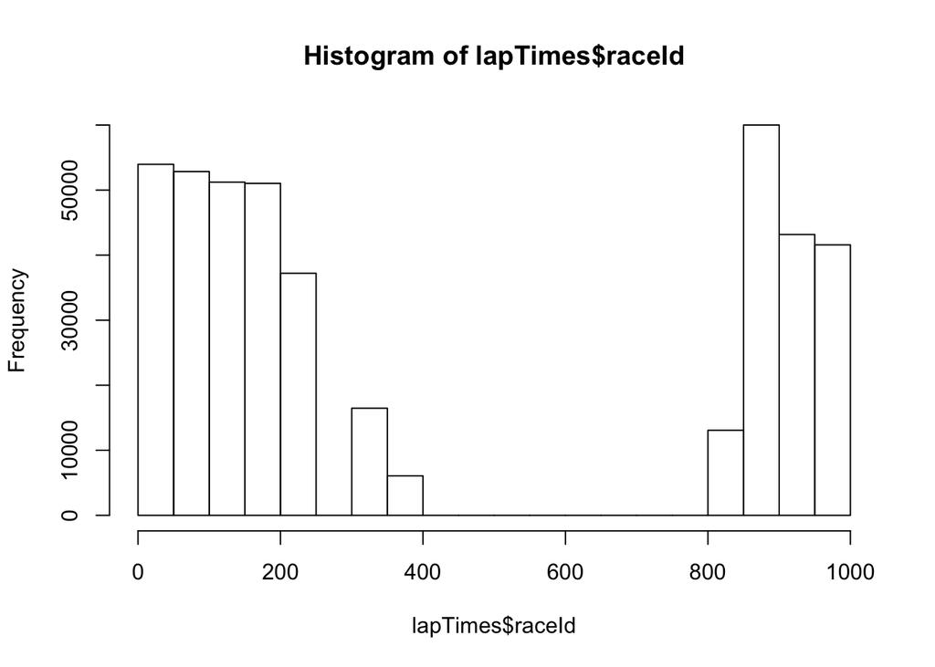

```r
# manually handle the 7 records that failed to parse and re-run lubridate
drivers[c(590, 704, 742, 751, 761, 787, 792), "dob"] <-
  c("1899-08-03", "1898-11-01", "1896-12-28", "1899-10-15", "1899-10-13", "1898-06-09", "1898-10-18")
drivers$dob <- ymd(drivers$dob)

# rename columns
drivers <- drivers %>%
  rename("driver_name" = "driverRef",
         "driver_dob" = "dob",
         "driver_nationality" = "nationality",
         "driver_url" = "url"
         )



## driverStandings ----------------------------------------------------------

# remove column: 'positionText' ('positionText' is identical to 'position' with the exception of 'D' for disqualification from the championship due to intentional collision)
driverStandings <- subset(driverStandings, select = -positionText)

# convert 'points' to int type
driverStandings$points <- as.integer(driverStandings$points)

# rename columns
driverStandings <- driverStandings %>%
  rename("driverStanding_runningTotalPointsInSeason" = "points",
         "driverStanding_runningPositionInSeason" = "position",
         "driverStanding_runningTotalWinsInSeason" = "wins"
         )



## lapTimes -----------------------------------------------------------------

# inspect distribution of lap times
hist(lapTimes$raceId)
```

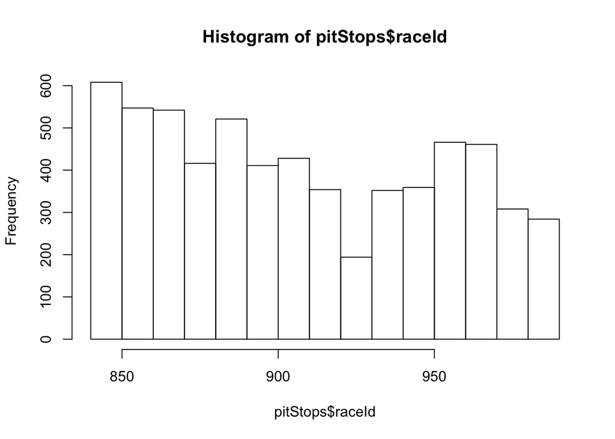

```r
# remove column: 'time' ('time' == 'milliseconds')
lapTimes <- subset(lapTimes, select = -time)

# create an average lap time column
lapTimes <- lapTimes %>%
  group_by(raceId, driverId) %>%
  mutate(lapTime_avgMillisec = as.integer(mean(milliseconds)))

# ungroup columns and convert back to data frame
lapTimes <- lapTimes %>%
  ungroup() %>%
  as.data.frame()

# rename columns
lapTimes <- lapTimes %>%
  rename("lapTime_positionInLap" = "position",
         "lapTime_millisec" = "milliseconds"
         )



## pitStops -----------------------------------------------------------------

# inspect distribution of pit stops
hist(pitStops$raceId)
```

```r
# remove column: 'duration' ('duration' == 'milliseconds')
pitStops <- subset(pitStops, select = -duration)

# create a total number of stops per race column
pitStops <- pitStops %>%
    group_by(raceId, driverId) %>%
    arrange(raceId, driverId, stop) %>%
    mutate(pitStop_totalStops = last(stop))

# create an average pitstop duration column
pitStops <- pitStops %>%
    group_by(raceId, driverId) %>%
    mutate(pitStop_avgDuration = as.integer(mean(milliseconds)))

# ungroup columns and convert back to data frame
pitStops <- pitStops %>%
  ungroup() %>%
  as.data.frame()

# rename columns
pitStops <- pitStops %>%
  rename("pitStop_stopNum" = "stop",
         "pitStop_lap" = "lap",
         "pitStop_timeOfDay" = "time",
         "pitStop_durationMillisec" = "milliseconds"
         )



## qualifying ---------------------------------------------------------------

# remove column: 'number' ('number' is arbitrary driver/car number)
qualifying <- subset(qualifying, select = -number)

# correct erroneous record in q2
qualifying[5663, "q2"] <- "1:48.552"

# convert 'q1':'q3' to milliseconds
qualifying <- qualifying %>%
  separate(q1, into = c("q1_minuteSecond", "q1_decimal"), sep = "\\.") %>%
  separate(q1_minuteSecond, into = c("q1_minute", "q1_second"), convert = TRUE) %>%
  mutate(q1_milliseconds = paste0(((q1_minute * 60) + q1_second), q1_decimal))

qualifying <- qualifying %>%
  separate(q2, into = c("q2_minuteSecond", "q2_decimal"), sep = "\\.") %>%
  separate(q2_minuteSecond, into = c("q2_minute", "q2_second"), convert = TRUE) %>%
  mutate(q2_milliseconds = paste0(((q2_minute * 60) + q2_second), q2_decimal))

qualifying <- qualifying %>%
  separate(q3, into = c("q3_minuteSecond", "q3_decimal"), sep = "\\.") %>%
  separate(q3_minuteSecond, into = c("q3_minute", "q3_second"), convert = TRUE) %>%
  mutate(q3_milliseconds = paste0(((q3_minute * 60) + q3_second), q3_decimal))

# convert 'NANA's (caused by concatenation) to NAs
qualifying[qualifying == "NANA"] <- NA

# remove columns: 'q1_minute' through 'q3_decimal' (temp columns created for parsing)
qualifying <- subset(qualifying, select = -c(q1_minute:q3_decimal))

# rename columns
qualifying <- qualifying %>%
  rename("qualifying_finishPosition" = "position",
         "qualifying_q1Millisec" = "q1_milliseconds",
         "qualifying_q2Millisec" = "q2_milliseconds",
         "qualifying_q3Millisec" = "q3_milliseconds"
         )



## races --------------------------------------------------------------------

# convert 'date' to date type
races$date <- ymd(races$date)

# convert 'time' to time type
races$time <- times(races$time)

# rename columns
races <- races %>%
  rename("race_year" = "year",
         "race_round" = "round",
         "race_name" = "name",
         "race_date" = "date",
         "race_time" = "time",
         "race_url" = "url"
         )



## results ------------------------------------------------------------------

# remove columns: 'position', 'number', 'time', 'fastestLap', 'rank', 'fastestLapTime', 'fastestLapSpeed'
# ('position' is redundant, 'number' is arbitrary driver/car number, 'time' is represented more cleanly in 'milliseconds')
results <- subset(results, select = -c(position, number, time))

# convert positionText column to finish description
results <- mutate(results, result_finishDescription =
                  ifelse(results$positionText == "D", "Disqualified",
                  ifelse(results$positionText == "E", "Excluded",
                  ifelse(results$positionText == "F", "FailedToFinish",
                  ifelse(results$positionText == "N", "NotClassified",
                  ifelse(results$positionText == "R", "Retired",
                  ifelse(results$positionText == "W", "Withdrew",
                  "Finished"
                  )))))))
results <- subset(results, select = -positionText)

# convert fastestLapTime to milliseconds
results <- results %>%
  separate(fastestLapTime, into = c("fLT_minuteSecond", "fLT_decimal"), sep = "\\.") %>%
  separate(fLT_minuteSecond, into = c("fLT_minute", "fLT_second"), convert = TRUE) %>%
  mutate(fLT_milliseconds = paste0(((fLT_minute * 60) + fLT_second), fLT_decimal, "00"))

# convert 'NANA00's (caused by concatenation) to NAs
results$fLT_milliseconds[results$fLT_milliseconds == "NANA00"] <- NA

# convert 'points', 'fastestLapSpeed', and 'fLT_milliseconds' to appropriate number types
results$points <- as.integer(results$points)
results$fLT_milliseconds <- as.integer(results$fLT_milliseconds)
results$fastestLapSpeed <- as.double(results$fastestLapSpeed)
# remove columns: 'q1_minute' through 'q3_decimal' (temp columns created for parsing)
results <- subset(results, select = -c(fLT_minute:fLT_decimal))

# rename columns
results <- results %>%
  rename("result_startingGridPosition" = "grid",
         "result_finishOrder" = "positionOrder",
         "result_pointsEarned" = "points",
         "result_lapsCompleted" = "laps",
         "result_finishTimeMillisec" = "milliseconds",
         "result_fastestLapTimeMillisec" = "fLT_milliseconds",
         "result_fastestLap" = "fastestLap",
         "result_fastestLapRank" = "rank",
         "result_fastestLapSpeed" = "fastestLapSpeed"
         )



## seasons ------------------------------------------------------------------

# convert year to date type
seasons$year <- as.character(seasons$year)
seasons$year <- as.Date(paste(seasons$year, 1, 1, sep = "-")) # beginning of year
seasons$year <- as.Date(paste(seasons$year, 12, 31, sep = "-")) # end of year

# rename columns
seasons <- seasons %>%
  rename("season_year" = "year",
         "season_url" = "url"
         )



## status ------------------------------------------------------------------

# rename column
colnames(status) [colnames(status) == "status"] <- "status_description"
```

### Files Merge and Additional Cleaning

```r
# read in country Codes
countryCodes <- read.csv("../Raw Source Data/countryCodes.csv", stringsAsFactors = FALSE)


# manually correct errors caused by accent marks
countryCodes[1214, 1] <- "Monegasque"


# join countryCodes to drivers and constructors to convert nationality to country
drivers <- drivers %>%
  left_join(countryCodes, by = c("driver_nationality" = "Nationality")) %>%
  select(-driver_nationality) %>%
  rename("driver_homeCountry" = "Country")

constructors <- constructors %>%
  left_join(countryCodes, by = c("constructor_nationality" = "Nationality")) %>%
  select(-constructor_nationality) %>%
  rename("constructor_homeCountry" = "Country")


# manually correct errors cause by compound nationalities (e.g. 'East German') or similar causes
drivers[496, 5] <- "Italy"
drivers[578, 5] <- "Italy"
drivers[714, 5] <- "Germany"
drivers[715, 5] <- "Germany"
drivers[718, 5] <- "Germany"

constructors[100, 4] <- "Belgium"
constructors[146, 4] <- "Germany"


# join countriesLatLong to drivers to obtain lat, long coordinates
# source: https://github.com/knowitall/chunkedextractor/blob/master/src/main/resources/edu/knowitall/chunkedextractor/demonyms.csv
countriesLatLong <- read.csv("../Raw Source Data/countries_LatLong.csv", stringsAsFactors = FALSE)

drivers <- drivers %>%
  left_join(countriesLatLong, by = c("driver_homeCountry" = "name")) %>%
  rename("driver_lat" = "latitude",
         "driver_long" = "longitude",
         )


# clean missing lat, long for "Rhodesia"
# arrange rows by driver_homeCountry
drivers <- drivers %>%
  arrange(driver_homeCountry)


# manually update missing lat, longs
drivers[445:448, 6] <- -19.0154381
drivers[445:448, 7] <- 29.1548576


# join countriesLatLong to constructors to obtain lat, long coordinates
# source: https://github.com/knowitall/chunkedextractor/blob/master/src/main/resources/edu/knowitall/chunkedextractor/demonyms.csv
constructors <- constructors %>%
  left_join(countriesLatLong, by = c("constructor_homeCountry" = "name")) %>%
  rename("constructor_lat" = "latitude",
         "constructor_long" = "longitude",
  )


# manually update missing lat, longs
constructors[93, 5] <- -19.0154381
constructors[93, 6] <- 29.1548576


# join source tables beginning from 'results' in reverse alphabetical order
# confirm primary key
results %>%
  count(resultId) %>%
  filter(n > 1)
```

```
## # A tibble: 0 x 2
## # … with 2 variables: resultId <int>, n <int>
```

```r
# join status
resultsHistorical <- results %>%
  left_join(status, by = "statusId") %>%
  select(-statusId)


# exclude seasons


# join races
resultsHistorical <- resultsHistorical %>%
  left_join(races, by = "raceId") %>%
  select(-race_name, -race_year, -race_time, -race_url)


# exclude qualifying


# exclude pitStops


# exclude lapTimes


# join driverStandings
# confirm primary key
driverStandings %>%
  count(raceId, driverId) %>%
  filter(n > 1)
```

```
## # A tibble: 0 x 3
## # … with 3 variables: raceId <int>, driverId <int>, n <int>
```

```r
resultsHistorical <- resultsHistorical %>%
  left_join(driverStandings, by = c("raceId", "driverId")) %>%
  select(-driverStandingsId)


# join drivers
resultsHistorical <- resultsHistorical %>%
  left_join(drivers, by = "driverId") %>%
  select(-driverId, -driver_url)


# join constructorStandings
# confirm primary key
constructorStandings %>%
  count(raceId, constructorId) %>%
  filter(n > 1)
```

```
## # A tibble: 0 x 3
## # … with 3 variables: raceId <int>, constructorId <int>, n <int>
```

```r
resultsHistorical <- resultsHistorical %>%
  left_join(constructorStandings, by = c("raceId", "constructorId")) %>%
  select(-constructorStandingsId)


# join constructors
resultsHistorical <- resultsHistorical %>%
  left_join(constructors, by = "constructorId") %>%
  select(-constructor_url)


# join constructorResults
# confirm primary key
constructorResults %>%
  count(raceId, constructorId) %>%
  filter(n > 1)
```

```
## # A tibble: 2 x 3
##   raceId constructorId     n
##    <int>         <int> <int>
## 1     75             7     2
## 2    903             3     2
```

```r
# remove duplicate records
constructorResults <- constructorResults[-c(9632, 10355),]

resultsHistorical <- resultsHistorical %>%
  left_join(constructorResults, by = c("raceId", "constructorId")) %>%
  select(-constructorResultsId, -constructorId)


# join circuits
resultsHistorical <- resultsHistorical %>%
  left_join(circuits, by = "circuitId") %>%
  select(-circuitId, -circuit_url, -circuit_lat, -circuit_long)




#### Clean Newly Merged Data Frame ####

# consider converting points earned to boolean
# consider creating a normalized column of % of total laps finished in previous race round

# inspect df (below 4 lines commented out for space-saving purposes)
# glimpse(resultsHistorical)
# summary(resultsHistorical)
# colSums(is.na(resultsHistorical))
# head(resultsHistorical)


#normalize laps completed field
resultsHistorical <- resultsHistorical %>%
  group_by(raceId) %>%
  mutate(maxLaps = max(result_lapsCompleted),
         result_percentOfRaceCompleted = (result_lapsCompleted / maxLaps) * 100,
         result_lapsCompleted = NULL,
         maxLaps = NULL
         )

# ungroup columns
resultsHistorical <- resultsHistorical %>%
  ungroup() %>%
  as.data.frame()


# remove resultId column which is no longer needed
resultsHistorical <- subset(resultsHistorical, select = -resultId)


# remove result_finishTimeMillisec due to difficult to handle NAs
resultsHistorical <- subset(resultsHistorical, select = -result_finishTimeMillisec)


# remove columns relating to fastest lap data which contain many untreatable NAs
resultsHistorical <- subset(resultsHistorical, select = -c(result_fastestLap:result_fastestLapSpeed, result_fastestLapTimeMillisec))


# fill NAs in 'points' & 'wins' related columns with 0 and remove 'position' related columns
  # NAs in 'driverStandings.' and 'consturctorStandings.' caused by failures to qualify in early season races
  # attempt later -- [fill NAs in 'position' columns with *max runningPositionsInSeason + 1* for each season]
    # use grouped mutate (window function)
resultsHistorical$driverStanding_runningTotalPointsInSeason[is.na(resultsHistorical$driverStanding_runningTotalPointsInSeason)] <- 0

resultsHistorical$driverStanding_runningTotalWinsInSeason[is.na(resultsHistorical$driverStanding_runningTotalWinsInSeason)] <- 0

resultsHistorical <- subset(resultsHistorical, select = -driverStanding_runningPositionInSeason)

resultsHistorical$constructorStanding_runningTotalPointsInSeason[is.na(resultsHistorical$constructorStanding_runningTotalPointsInSeason)] <- 0

resultsHistorical$constructorStanding_runningTotalWinsInSeason[is.na(resultsHistorical$constructorStanding_runningTotalWinsInSeason)] <- 0

resultsHistorical$constructorResult_pointsPerRace[is.na(resultsHistorical$constructorResult_pointsPerRace)] <- 0

resultsHistorical <- subset(resultsHistorical, select = -constructorStanding_runningPositionInSeason)


# create driver age at time of race feature and convert to int
# remove 'driver_dob' (consider re-adding in future to analyze race results on closeness to birthday)
resultsHistorical <- resultsHistorical %>%
  mutate(driverAge = (race_date - driver_dob) / 365,
         driver_dob = NULL
         )

resultsHistorical$driverAge <- as.integer(resultsHistorical$driverAge)


# correct outlier
resultsHistorical[17012, "driverAge"] = 33


# convert race date to month and year columns (for better factorization)
# remove 'race_date'
resultsHistorical <- resultsHistorical %>%
  mutate(race_month = month(race_date),
         race_year = year(race_date),
         race_date = NULL
         )


# create race in driver home country? and constructor home country (True or False) feature and remove existing fields
# resultsHistorical <- resultsHistorical %>%
  # mutate(driverHomeCountry = (substr(circuit_country, 1, 3) == substr(driver_nationality, 1, 3)),
         # constructorHomeCountry = (substr(circuit_country, 1, 3) == substr(constructor_nationality, 1, 3)),
         # driver_nationality = NULL,
         # constructor_nationality = NULL,
         # circuit_country = NULL
         # )


# create running total points going into race for driver and constructor and remove existing columns
resultsHistorical <- resultsHistorical %>%
  mutate(driver_preRaceTotPoints = driverStanding_runningTotalPointsInSeason - result_pointsEarned,
         constructor_preRaceTotPoints = constructorStanding_runningTotalPointsInSeason - constructorResult_pointsPerRace,
         )


# correct for inaccurate observations (i.e. negative points) caused by NAs from disqualification, failure to qualify, etc.
# 1 error in driverPoints
resultsHistorical$driver_preRaceTotPoints <- ifelse(resultsHistorical$driver_preRaceTotPoints < 0, 0, resultsHistorical$driver_preRaceTotPoints)


# ~50 errors in constructor points
resultsHistorical$constructor_preRaceTotPoints <- ifelse(resultsHistorical$constructor_preRaceTotPoints < 0, 0, resultsHistorical$constructor_preRaceTotPoints)


# remove unnecessary columns
resultsHistorical <- subset(resultsHistorical, select = -c(driverStanding_runningTotalPointsInSeason, constructorStanding_runningTotalPointsInSeason))


# create running total wins going into race for driver and constructor and remove existing columns
resultsHistorical <- resultsHistorical %>%
  mutate(driver_preRaceTotWins = ifelse(result_finishOrder == 1, driverStanding_runningTotalWinsInSeason - 1, driverStanding_runningTotalWinsInSeason),
         driverStanding_runningTotalWinsInSeason = NULL
         )

resultsHistorical <- resultsHistorical %>%
  group_by(raceId, constructor_name) %>%
  mutate(constructor_preRaceTotWins = ifelse(min(result_finishOrder) == 1, constructorStanding_runningTotalWinsInSeason - 1, constructorStanding_runningTotalWinsInSeason),
         constructorStanding_runningTotalWinsInSeason = NULL
         )


# ungroup columns
resultsHistorical <- resultsHistorical %>%
  ungroup() %>%
  as.data.frame()


# correct for inaccurate observations (i.e. negative points) caused by NAs from disqualification, failure to qualify, etc.
# >200  in constructorTotWins
resultsHistorical$constructor_preRaceTotWins <- ifelse(resultsHistorical$constructor_preRaceTotWins < 0, 0, resultsHistorical$constructor_preRaceTotWins)


# remove unnecessary columns
resultsHistorical <- subset(resultsHistorical, select = -c(raceId, constructorResult_pointsPerRace))


# create features which contain previous race results and remove current race result fields
resultsHistorical <- resultsHistorical %>%
  arrange(driver_name, race_year, race_round) %>%
  mutate(result_percentOfPreviousRaceCompleted = ifelse(driver_name == lag(driver_name) & !is.na(lag(driver_name)), lag(result_percentOfRaceCompleted), 0),
         result_previousFinishDescrip = ifelse(driver_name == lag(driver_name) & !is.na(lag(driver_name)), lag(result_finishDescription), "First race"),
         status_previousDescrip = ifelse(driver_name == lag(driver_name) & !is.na(lag(driver_name)), lag(status_description), "First race"),
         result_percentOfRaceCompleted = NULL,
         result_finishDescription = NULL,
         status_description = NULL
         )


# convert columns (driverAge, percentOfPreviousRaceCompleted, preRaceTotPoints, preRaceTotWins) to integers
resultsHistorical$driverAge <- as.integer(resultsHistorical$driverAge)
resultsHistorical$result_percentOfPreviousRaceCompleted <- as.integer(resultsHistorical$result_percentOfPreviousRaceCompleted)
resultsHistorical$driver_preRaceTotPoints <- as.integer(resultsHistorical$driver_preRaceTotPoints)
resultsHistorical$driver_preRaceTotWins <- as.integer(resultsHistorical$driver_preRaceTotWins)


# convert pointsEarned to boolean
resultsHistorical <- resultsHistorical %>%
  mutate(result_inThePoints = ifelse(result_pointsEarned > 0, TRUE, FALSE),
         result_pointsEarned = NULL
  )


# arrange rows
resultsHistorical <- resultsHistorical %>%
  arrange(race_year, race_round, result_finishOrder, result_startingGridPosition)


# arrange columns
resultsHistorical <- resultsHistorical[, c("result_finishOrder", "result_inThePoints", "result_startingGridPosition",
                                           "driver_name", "constructor_name", "circuit_name", "circuit_city", "race_month",
                                           "race_year", "race_round", "driverAge", "driver_homeCountry", "driver_lat", "driver_long",
                                           "constructor_homeCountry", "constructor_lat", "constructor_long",
                                           "result_percentOfPreviousRaceCompleted", "result_previousFinishDescrip",
                                           "status_previousDescrip", "driver_preRaceTotPoints", "constructor_preRaceTotPoints",
                                           "driver_preRaceTotWins", "constructor_preRaceTotWins")]


# remove columns due to appeared unreliability
resultsHistorical <- subset(resultsHistorical, select = -c(constructor_preRaceTotPoints, constructor_preRaceTotWins))
```

## Intended algorithms to be used and rationale

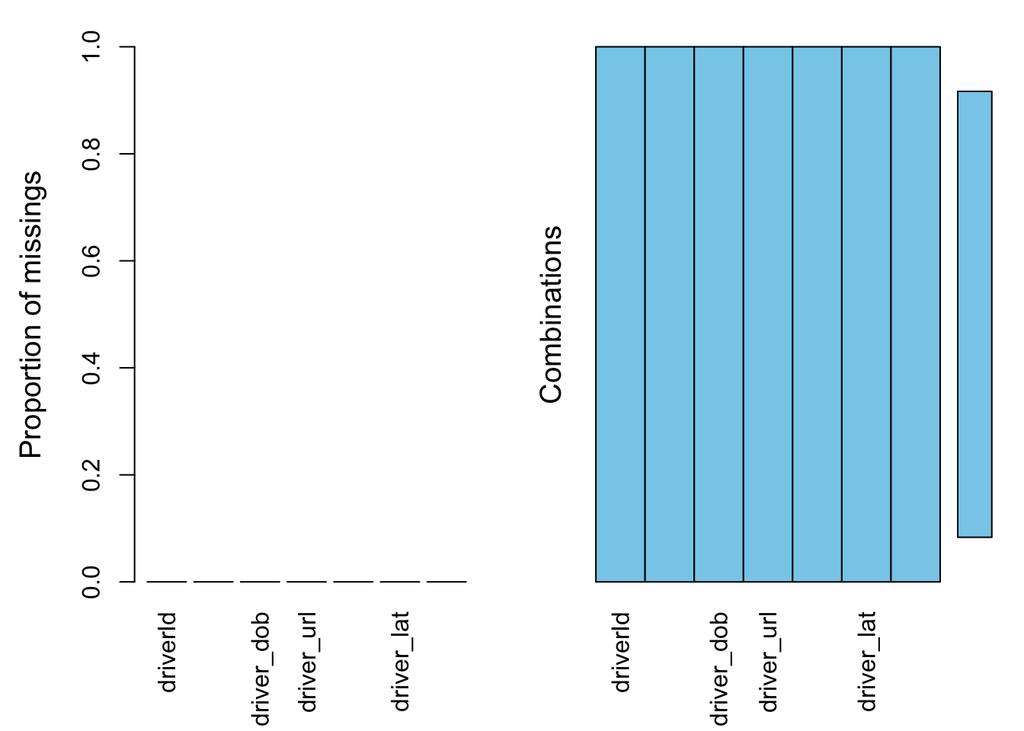

```r
#### Explore data ####

# confirm no missing values
aggr(drivers)
```

```r
## K-means -----------------------------------------------------------------

# incorporate lat long of driver homes to get clusters of where they come from
# then use cluster association as new feature for prediction

# partition the data
driversLatLong <- drivers[,c(2, 6:7)]


# convert driver name to factor
driversLatLong$driver_name <- as.factor(driversLatLong$driver_name)


# set seed for randmozing data
set.seed(20)


# run k-means
clusters <- kmeans(driversLatLong[,c(2:3)], 4)


# inspect cluters
str(clusters)
```

```
## List of 9
##  $ cluster     : int [1:848] 1 1 1 1 1 1 1 1 1 1 ...
##  $ centers     : num [1:4, 1:2] 21.53 49.66 -28.85 1.42 -86.67 ...
##   ..- attr(*, "dimnames")=List of 2
##   .. ..$ : chr [1:4] "1" "2" "3" "4"
##   .. ..$ : chr [1:2] "driver_lat" "driver_long"
##  $ totss       : num 3456348
##  $ withinss    : num [1:4] 272829 47434 586 84304
##  $ tot.withinss: num 405152
##  $ betweenss   : num 3051196
##  $ size        : int [1:4] 248 521 27 52
##  $ iter        : int 2
##  $ ifault      : int 0
##  - attr(*, "class")= chr "kmeans"
```

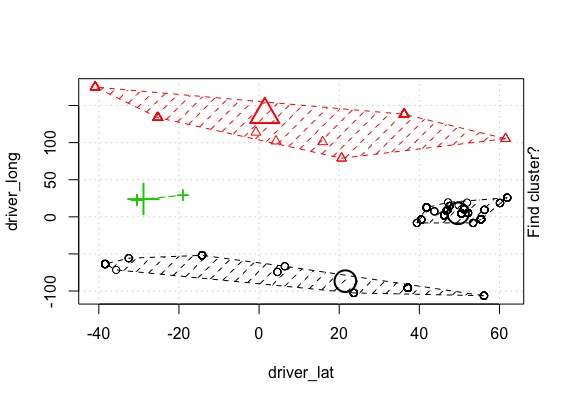

k-means plot

```r
# plot clusters (attempt multiple times if necessary)
num_clusters <- 4

# driverClust <- kmeans.ani(driversLatLong[,c(2:3)], num_clusters)
# above line commented out for report compilation purposes
```

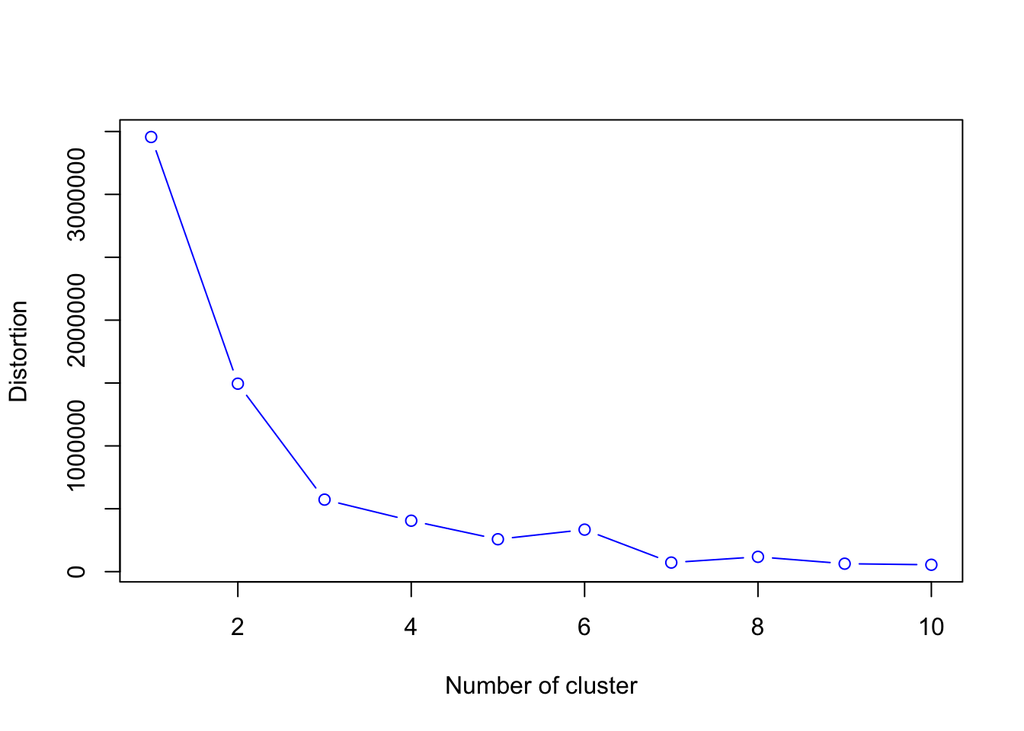

```r
# save the cluster number in the dataset as column 'driverHomeCluster'
driversLatLong <- driversLatLong %>%
  mutate(driverCluster = as.factor(clusters$cluster))


# create a function that returns the value of totwithinss, and takes inputdataset and number of clusters
# credit: Dr. Binh Zhang, The University of Arizona
kmeans.totwithinss.k <- function(dataset, number_of_centers){
  km <- kmeans(dataset, number_of_centers)
  km$tot.withinss
  }


# create a function that returns a series of totwithinss values, and takes input maxk
# vec is a vector that contains totwithinss values associated with k from 1 to maxk
# credit: Dr. Binh Zhang, The University of Arizona
kmeans.distortion <- function(dataset, maxk){
  vec <- as.vector(1:maxk)
  vec[1:maxk] <- sapply(1:maxk, kmeans.totwithinss.k, dataset = dataset)
  return (vec)
  }


# plot elbow curve
maxk <- 10

dist_vect <- kmeans.distortion(driversLatLong[,c(2:3)], maxk)

plot(1:maxk, # horizontal axis
     dist_vect, # vertical axis
     type= 'b', # curve
     col = 'blue',
     xlab = "Number of cluster",
     ylab = "Distortion"
     )
```

```r
# reintroduce cluster results to resultsHistorical
driversLatLong <- subset(driversLatLong, select = -c(driver_lat, driver_long))

resultsHistorical <- resultsHistorical %>%
  left_join(driversLatLong, by = "driver_name")




#### Predict ####

## Naieve Bayes ------------------------------------------------------------

# review the data (below 2 lines commented out for space-saving purposes)
# summary(resultsHistorical)
# glimpse(resultsHistorical)

# clean dataset
resultsNB <- subset(resultsHistorical, select = -c(
  result_finishOrder,driver_lat, driver_long, constructor_lat, constructor_long)
  )


# partition data for training and testing
sample_size <- floor(0.7 * nrow(resultsNB))

training_index <- sample(nrow(resultsNB), size = sample_size, replace = FALSE)
train <- resultsNB[training_index,]
test <- resultsNB[-training_index,]


# check dimensions of partitions
dim(train)
```

```
## [1] 17326    18
```

```r
dim(test)
```

```
## [1] 7426   18
```

```r
# fit model
results.model <- naiveBayes(result_inThePoints ~ . , data = train)

# review model (below line commented out for space-saving purposes)
# results.model

# test model
results.predict <- predict(results.model, test, type = 'class')


# test model against recent Brazil Grand Prix results
testBrazil <- read.csv("../Processed Data/brazil2019.csv")

# factorize driverCluster dimension
testBrazil$driverCluster <- as.factor(testBrazil$driverCluster)

results.predict2 <- predict(results.model, testBrazil, type = 'class')

resultsNB_output2 <- data.frame(driver_name = testBrazil[,'driver_name'], predicted = results.predict2, actual = testBrazil[,'result_inThePoints'])
```